# 3. Project Management: Let’s Get Organized

Know where you are…

**Learning objectives**

- Understand motivation for project based workflows
- Know how to organize code, data, and results
- Know the basics of file paths and directory structures
- Be able to create and use an RStudio project

## Where Am I?

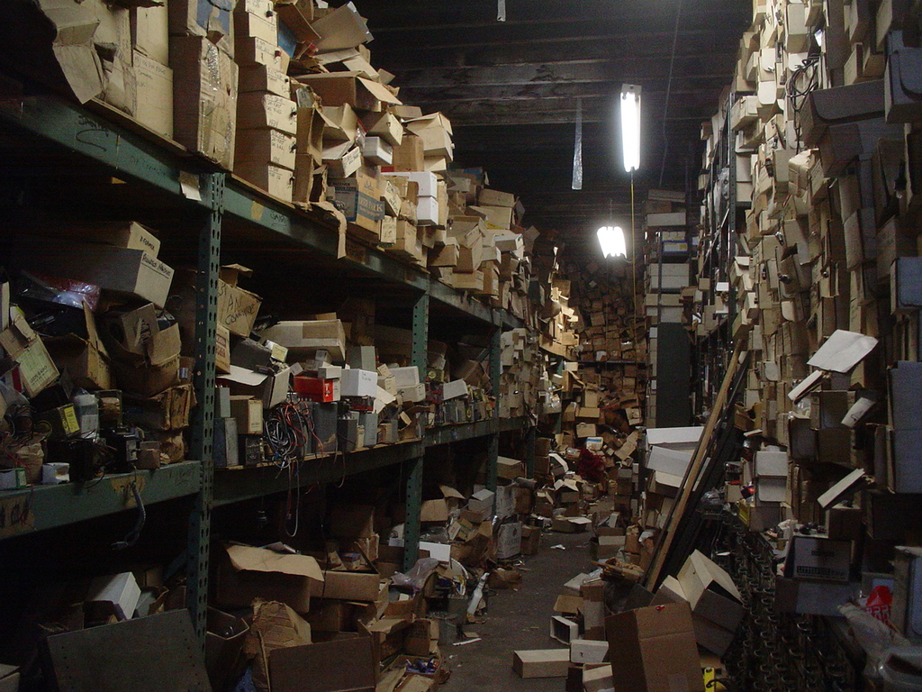

Figure 1: *A disorganized system for finding things*

Any time you are working on your computer, you must navigate amidst a forest of files and folders.

> One of the most common issues we deal with in `R` programming is to **tell your computer where a file or folder is located**.

## Use Project Workflows

One of the great advantages of using tools like RStudio is they make it easy to use an organized “**project**” workflow. What do we mean by “**using projects**”? Projects refer to a general pattern or structure used for each work project or analysis. This approach is not specific to `R`. Any practiced data scientist will use a folder structure and organization scheme, no matter what programming language they use.

The general idea is to always use the same structure and naming schemes across every project. Do this every single time with every single project you make, in order to make it a habit. This will save you time and brainpower! Imagine quickly moving between tasks or projects with minimal time spent “*trying to find where things are and getting oriented*”. You’ll always know where things should be!

### Basic Folders for Every Project

At a minimum, it’s useful to have separate directories (folders) for each of the following:

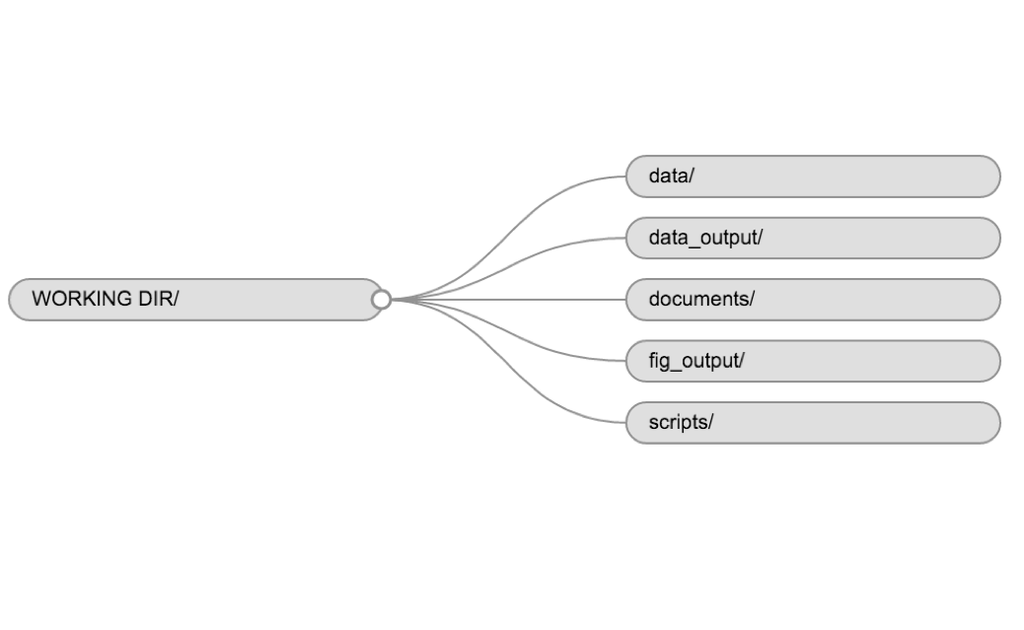

Figure 2: *An example project folder structure*

### RStudio Projects

Within the R environment, something that makes project management and organization much easier is the use of RStudio Projects (`.Rproj` file). RStudio makes the use of Projects straightforward. One of the nicest parts of using **RStudio Projects** is that they automatically set the working directory to the folder containing a specified `.RProj` file. You can make any existing folder an RProject folder, or make a new one. RStudio projects are a great way to quickly and easily organize your workflows; each project can be a specific task, or a larger set of objectives you need to complete. With **RStudio Projects**, it’s easy to switch between projects, or work on different projects simultaneously without much mental overload, *especially if you use the same project folder structure across each project*!

Avoid using `setwd()`! More reasons and rationale [linked here](https://rstats.wtf/project-oriented-workflow.html#setwd).

### Setting up an `.Rproj`

Let’s create an RStudio Project as part of this course that you can use throughout each module. We highly recommend that no matter what you are working on in `R`, that you try to do it within the structure of an RStudio Project!

1. Open RStudio and navigate to the upper right-hand side where it says “**Project: (None)**”. If we click on this button, we should see some options. Select **New Project**.
2. We can use either a New Directory, or setup a project in an Existing Directory. Both give similar options.
3. Select “**New Project**”

[figure not shown]

Figure 3: *RStudio Project setup*

4. Make a new sub-directory folder (if you don’t have it) under your Documents folder called: **`Rprojects`**

It’s a good idea to keep all your R projects in one place. You can decide if this should be in your **`~/Documents`** folder, or somewhere else (associated with a version control or cloud service like Dropbox/Box/etc).

5. Finally, we can name our new project (remember no spaces in our folder/file names!): **`intro_r4wrds`**

[figure not shown]

Figure 4: *Make a new project named **intro_r4wrds***

### Make Folders & Add Data

Great! Now we can create a folder structure in our project as discussed in the Basic Folders for Every Project section above. More importantly, we can also put all our [course data](https://www.r4wrds.com/intro/m_install_r#step-5.-download-workshop-datasets) into the **`data`** folder in your RStudio project.

We can download data directly via the `download.file()` function. In your `Console` tab, you can enter this code to download the data into your `data` folder!

```r
# downloads the file (data.zip) to your data directory
download.file("https://github.com/r4wrds/r4wrds-data-intro/raw/main/data.zip",
              destfile = "data/data.zip")

# unzip the datasets for the course:
unzip(zipfile = "data/data.zip")
```